# Titanic Survival Prediction

The sinking of the Titanic is one of the most infamous shipwrecks in history.

On April 15, 1912, during her maiden voyage, the widely considered “unsinkable” RMS Titanic sank after colliding with an iceberg. Unfortunately, there weren’t enough lifeboats for everyone onboard, resulting in the death of 1502 out of 2224 passengers and crew.

While there was some element of luck involved in surviving, it seems some groups of people were more likely to survive than others.

In this project, a predictive model is being developed that tries to answer the question: “what sorts of people were more likely to survive?” using passenger data (ie name, age, gender, socio-economic class, etc).

The data was acquired from [Kaggle](https://www.kaggle.com/c/titanic).

The GitHub repository for this project can be found [here](https://github.com/nicksento/Titanic-Survival-Prediction).

# Import Libraries

```python
# Data Manipulation
import pandas as pd
import numpy as np

# Data Visualization
import seaborn as sns
import matplotlib.pyplot as plt
import missingno
%matplotlib inline
plt.style.use('fivethirtyeight')

# Machine Learning
from sklearn.model_selection import train_test_split
from sklearn.linear_model import LogisticRegression
from sklearn.metrics import classification_report
from sklearn.metrics import confusion_matrix
from sklearn.metrics import plot_confusion_matrix
from sklearn.metrics import accuracy_score
from sklearn.naive_bayes import GaussianNB
from sklearn.neighbors import KNeighborsClassifier
from sklearn.tree import DecisionTreeClassifier
from sklearn.ensemble import RandomForestClassifier
from sklearn import svm

import warnings
warnings.filterwarnings('ignore')
```

# Read Data

```python
titanic_df = pd.read_csv('data/train.csv')
titanic_df.head()
```

|  | PassengerId | Survived | Pclass | Name | Sex | Age | SibSp | Parch | Ticket | Fare | Cabin | Embarked |
| --- | --- | --- | --- | --- | --- | --- | --- | --- | --- | --- | --- | --- |
| 0 | 1 | 0 | 3 | Braund, Mr. Owen Harris | male | 22.0 | 1 | 0 | A/5 21171 | 7.2500 | NaN | S |
| 1 | 2 | 1 | 1 | Cumings, Mrs. John Bradley (Florence Briggs Th... | female | 38.0 | 1 | 0 | PC 17599 | 71.2833 | C85 | C |
| 2 | 3 | 1 | 3 | Heikkinen, Miss. Laina | female | 26.0 | 0 | 0 | STON/O2. 3101282 | 7.9250 | NaN | S |
| 3 | 4 | 1 | 1 | Futrelle, Mrs. Jacques Heath (Lily May Peel) | female | 35.0 | 1 | 0 | 113803 | 53.1000 | C123 | S |
| 4 | 5 | 0 | 3 | Allen, Mr. William Henry | male | 35.0 | 0 | 0 | 373450 | 8.0500 | NaN | S |

## Data Description

**Survival:** 0 = No, 1 = Yes

**Pclass (Ticket class):** 1 = 1st, 2 = 2nd, 3 = 3rd

**Sex:** Gender

**Age:** Age in years

**SibSp:** number of siblings/spouses aboard the Titanic

**Parch:** number of parents/children aboard the Titanic

**Ticket:** Ticket number

**Fare:** Passenger fare

**Cabin:** Cabin number

**Embarked:** Port of Embarkation, C = Cherbourg, Q = Queenstown, S = Southampton

```python
titanic_df.shape
```

```
(891, 12)
```

891 instances in the dataset which is a very small dataset by Machine Learning standards

```python
titanic_df.isnull().sum()
```

```
PassengerId      0
Survived         0
Pclass           0
Name             0
Sex              0
Age            177
SibSp            0
Parch            0
Ticket           0
Fare             0
Cabin          687
Embarked         2
dtype: int64
```

Age feature is missing 177 values, Cabin 687 and Embarked 2. This information must be taken into account before feeding the data to the machine learning algorithm.

# Data Visualization

### Target feature: Survived

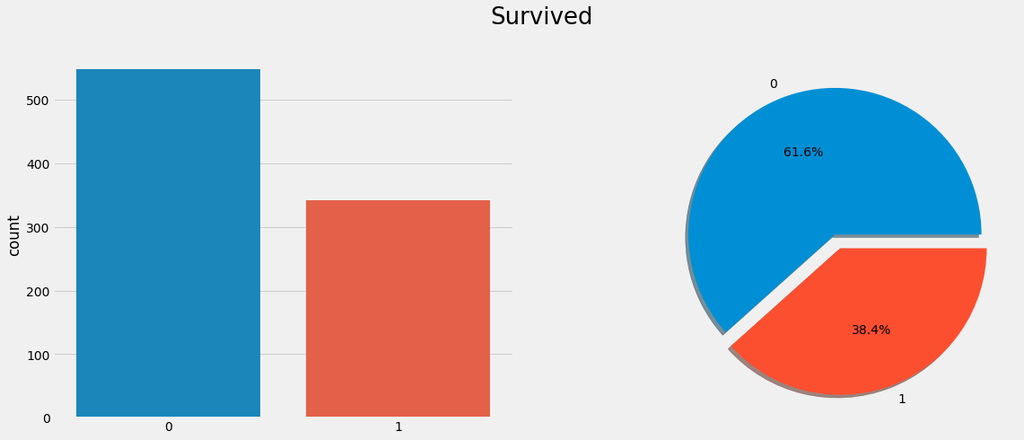

```python
fig, ax = plt.subplots(1, 2, figsize=(18,7))
fig.suptitle('Survived', fontsize=26)

sns.countplot('Survived', data=titanic_df, ax=ax[0])
ax[0].set_xlabel('')

titanic_df['Survived'].value_counts().plot.pie(explode=[0,0.1],autopct='%1.1f%%', shadow=True, ax=ax[1])
ax[1].set_ylabel('')

plt.show()
```

0: The passenger did not survive  
1: The passenger survived

61.6% of the dataset's passengers did not survive

### Feature: Pclass

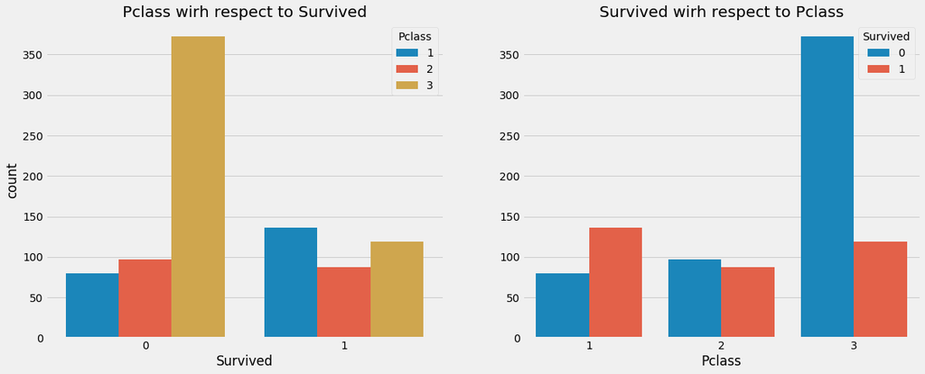

```python
fig, ax = plt.subplots(1, 2, figsize=(18,7))

sns.countplot('Survived', hue='Pclass', data=titanic_df, ax=ax[0])
ax[0].set_title('Pclass wirh respect to Survived')

sns.countplot( 'Pclass',hue='Survived', data=titanic_df, ax=ax[1])
ax[1].set_ylabel('')
ax[1].set_title('Survived wirh respect to Pclass')

plt.show()
```

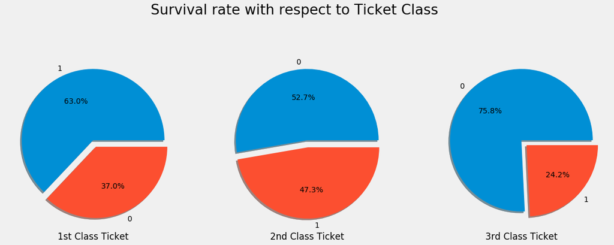

```python
pclass1 = titanic_df.loc[titanic_df.Pclass==1]
pclass2 = titanic_df.loc[titanic_df.Pclass==2]
pclass3 = titanic_df.loc[titanic_df.Pclass==3]

fig, ax = plt.subplots(1, 3, figsize=(18,7))
fig.suptitle('Survival rate with respect to Ticket Class ', fontsize=26)

pclass1['Survived'].value_counts().plot.pie(explode=[0,0.1],autopct='%1.1f%%', shadow=True, ax=ax[0])
pclass2['Survived'].value_counts().plot.pie(explode=[0,0.1],autopct='%1.1f%%', shadow=True, ax=ax[1])
pclass3['Survived'].value_counts().plot.pie(explode=[0,0.1],autopct='%1.1f%%', shadow=True, ax=ax[2])

ax[0].set_ylabel('')
ax[1].set_ylabel('')
ax[2].set_ylabel('')

ax[0].set_xlabel('1st Class Ticket')
ax[1].set_xlabel('2nd Class Ticket')
ax[2].set_xlabel('3rd Class Ticket')

plt.show()
```

First class ticket passengers were the only ones with a higher chance of surviving than dying.  
Second class ticket passengers had almost 50% rate of survival.  
Only 24.2% of third class ticket passengers survived.

### Feature: Name

```python
titanic_df.Name.describe()
```

```
count                          891
unique                         891
top       Keane, Mr. Andrew "Andy"
freq                             1
Name: Name, dtype: object
```

The dataset has 891 unique names. This feature will not be used in the current analysis. It could be used to fill in age missing values and to further analyze passengers' relationships.

### Feature: Sex

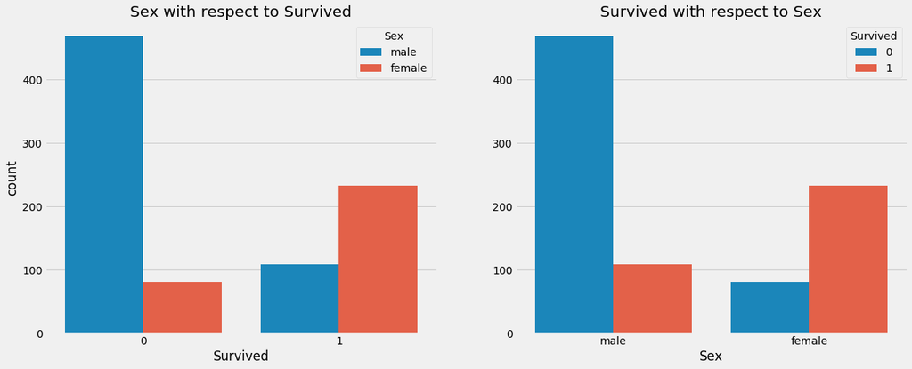

```python
fig, ax = plt.subplots(1, 2, figsize=(18,7))

sns.countplot('Survived', hue='Sex', data=titanic_df, ax=ax[0])
ax[0].set_title('Sex with respect to Survived')

sns.countplot( 'Sex',hue='Survived', data=titanic_df, ax=ax[1])
ax[1].set_ylabel('')
ax[1].set_title('Survived with respect to Sex')

plt.show()
```

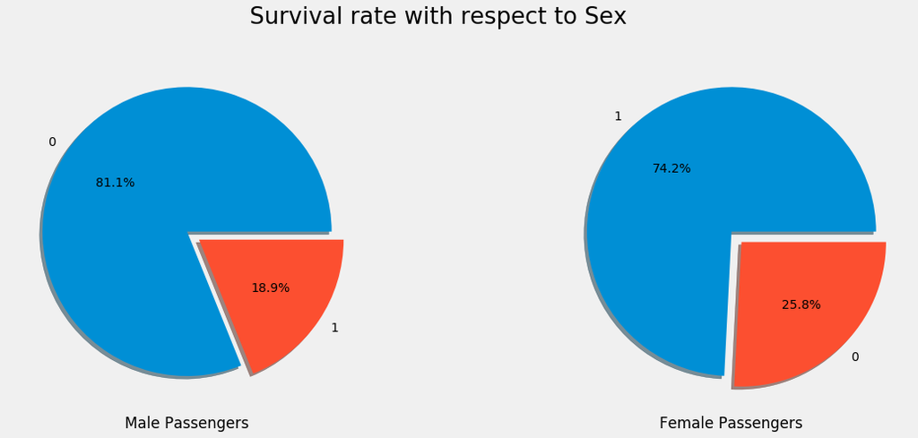

```python
male = titanic_df.loc[titanic_df.Sex=='male']
female = titanic_df.loc[titanic_df.Sex=='female']

fig, ax = plt.subplots(1, 2, figsize=(18,7))
fig.suptitle('Survival rate with respect to Sex ', fontsize=26)

male['Survived'].value_counts().plot.pie(explode=[0,0.1],autopct='%1.1f%%', shadow=True, ax=ax[0])
female['Survived'].value_counts().plot.pie(explode=[0,0.1],autopct='%1.1f%%', shadow=True, ax=ax[1])

ax[0].set_ylabel('')
ax[1].set_ylabel('')

ax[0].set_xlabel('Male Passengers')
ax[1].set_xlabel('Female Passengers')

plt.show()
```

```python
print('# of male passengers:', len(male))
print('# of female passengers:', len(female))
print(int(577*0.189), 'male passengers survived')
print(int(314*0.742), 'female passengers survived')
```

```
# of male passengers: 577
# of female passengers: 314
109 male passengers survived
232 female passengers survived
```

Male passengers had only 18.9% chance of survival whereas female passengers had 74.2%

### Feature: Age

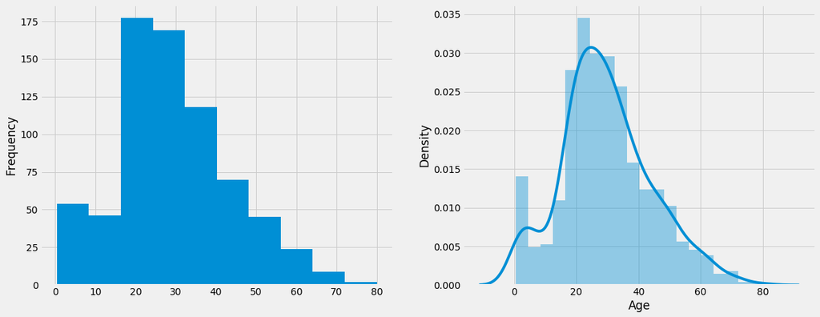

```python
fig, ax = plt.subplots(1, 2, figsize=(18,7))

titanic_df.Age.plot.hist(ax=ax[0])

age = titanic_df.dropna(subset=['Age'])
sns.distplot(age.Age, ax=ax[1])

plt.show()
```

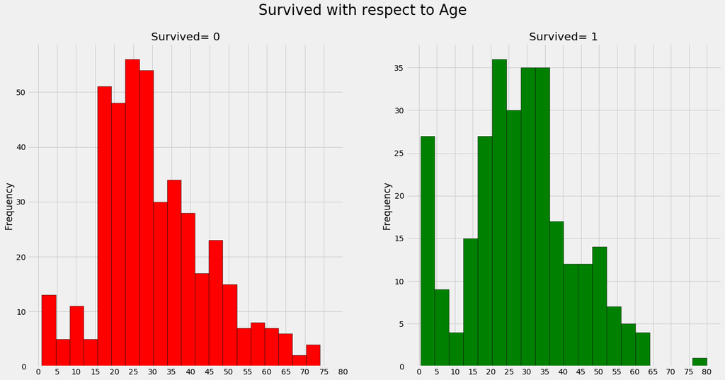

```python
fig, ax=plt.subplots(1,2,figsize=(20,10))
fig.suptitle('Survived with respect to Age', fontsize=26)

titanic_df[titanic_df['Survived']==0].Age.plot.hist(ax=ax[0],bins=20,edgecolor='black',color='red')
ax[0].set_title('Survived= 0')
x1=list(range(0,85,5))
ax[0].set_xticks(x1)

titanic_df[titanic_df['Survived']==1].Age.plot.hist(ax=ax[1],color='green',bins=20,edgecolor='black')
ax[1].set_title('Survived= 1')
x2=list(range(0,85,5))
ax[1].set_xticks(x2)

plt.show()
```

Children under the age of ten and the elderly over 75 had a higher chance of surviving.

### Feature: SibSp

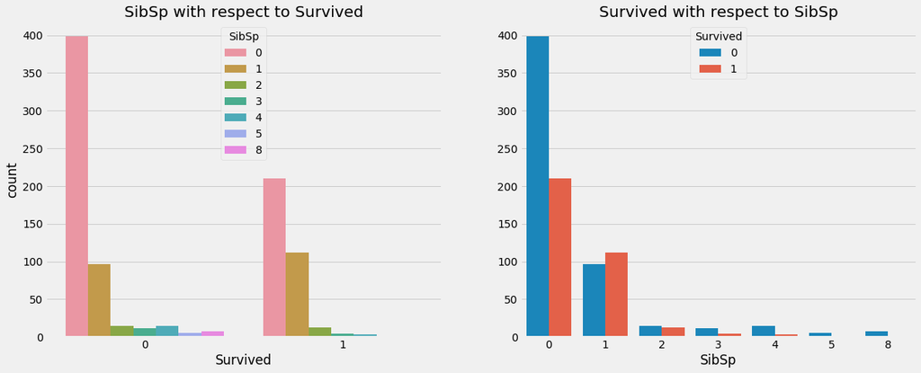

```python
fig, ax = plt.subplots(1, 2, figsize=(18,7))

sns.countplot('Survived', hue='SibSp', data=titanic_df, ax=ax[0])
ax[0].set_title('SibSp with respect to Survived')

sns.countplot('SibSp', hue='Survived', data=titanic_df, ax=ax[1])
ax[1].set_ylabel('')
ax[1].set_title('Survived with respect to SibSp')

plt.show()
```

If a passenger had one sibling or spouse aboard the ship, he/she had higher chance of surviving.

### Feature: Parch

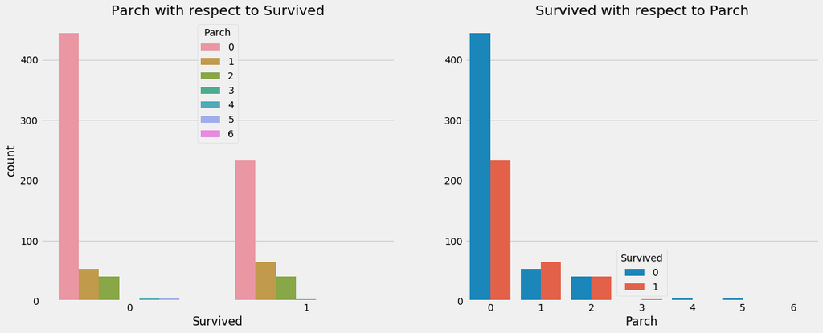

```python
fig, ax = plt.subplots(1, 2, figsize=(18,7))

sns.countplot('Survived', hue='Parch', data=titanic_df, ax=ax[0])
ax[0].set_title('Parch with respect to Survived')

sns.countplot('Parch', hue='Survived', data=titanic_df, ax=ax[1])
ax[1].set_ylabel('')
ax[1].set_title('Survived with respect to Parch')

plt.show()
```

The result is similar to the siblings/spouse feature above. If there was one parent or one child on board, they had higher chance to survive.

### Feature: Ticket

```python
titanic_df.Ticket.describe()
```

```
count        891
unique       681
top       347082
freq           7
Name: Ticket, dtype: object
```

This feature will not be used in the current analysis.

### Feature: Fare

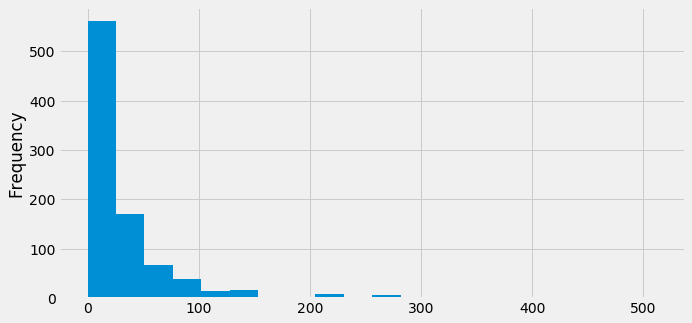

```python
titanic_df.Fare.plot.hist(bins=20, figsize=(10,5))
plt.show()
```

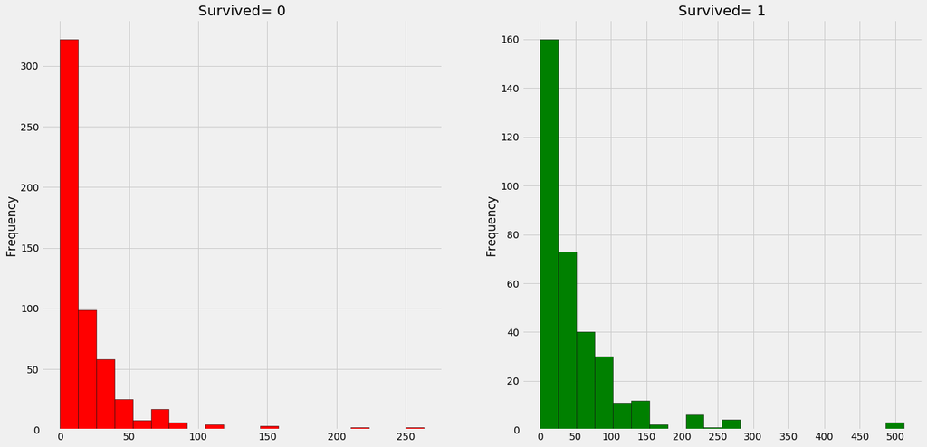

```python
f,ax=plt.subplots(1,2,figsize=(20,10))
fig.suptitle('Survived with respect to Age', fontsize=26)

titanic_df[titanic_df['Survived']==0].Fare.plot.hist(ax=ax[0],bins=20,edgecolor='black',color='red')
ax[0].set_title('Survived= 0')
x1=list(range(0,300,50))
ax[0].set_xticks(x1)

titanic_df[titanic_df['Survived']==1].Fare.plot.hist(ax=ax[1],color='green',bins=20,edgecolor='black')
ax[1].set_title('Survived= 1')
x2=list(range(0,550,50))
ax[1].set_xticks(x2)

plt.show()
```

### Feature: Cabin

```python
titanic_df.Cabin.isnull().sum()
```

```
687
```

The Cabin feature has 687 missing values so it won't be used in the current analysis.

### Feature: Embarked

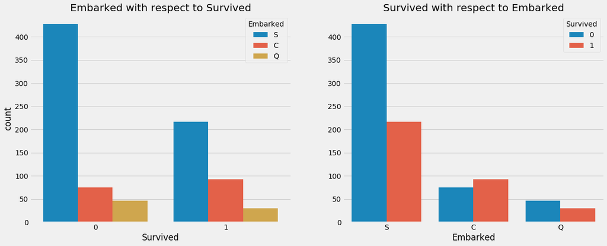

```python
fig, ax = plt.subplots(1, 2, figsize=(18,7))

sns.countplot('Survived', hue='Embarked', data=titanic_df, ax=ax[0])
ax[0].set_title('Embarked with respect to Survived')

sns.countplot('Embarked', hue='Survived', data=titanic_df, ax=ax[1])
ax[1].set_ylabel('')
ax[1].set_title('Survived with respect to Embarked')

plt.show()
```

An interesting information that can be extracted from this graph is the fact that those who embarked in Cherbourg had a higher chance of survival than those who embarked in Southampton or Queenstown. This might have occured because of the demographics of the passengers who embarked in Cherbourg.

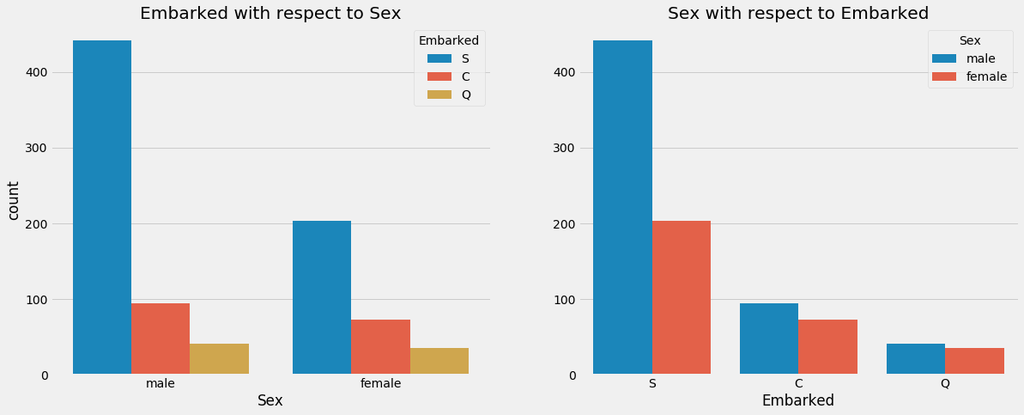

```python
fig, ax = plt.subplots(1, 2, figsize=(18,7))

sns.countplot('Sex', hue='Embarked', data=titanic_df, ax=ax[0])
ax[0].set_title('Embarked with respect to Sex')

sns.countplot('Embarked', hue='Sex', data=titanic_df, ax=ax[1])
ax[1].set_ylabel('')
ax[1].set_title('Sex with respect to Embarked')

plt.show()
```

```python
tot = len(titanic_df[titanic_df['Embarked']=='C'])
fem = len(titanic_df.loc[(titanic_df.Embarked=='C') & (titanic_df.Sex=='female')])
surC = len(titanic_df.loc[(titanic_df.Embarked=='C') & (titanic_df.Survived==1)])
print( '%.2f that embarked in Cherbourg were women' % (100*fem/tot))
print( '%.2f that embarked in Cherbourg survived' % (100*surC/tot))

tot = len(titanic_df[titanic_df['Embarked']=='Q'])
fem = len(titanic_df.loc[(titanic_df.Embarked=='Q') & (titanic_df.Sex=='female')])
surQ = len(titanic_df.loc[(titanic_df.Embarked=='Q') & (titanic_df.Survived==1)])
print( '%.2f that embarked in Queenstown were women' % (100*fem/tot))
print( '%.2f that embarked in Queenstown survived' % (100*surQ/tot))
```

```
43.45 that embarked in Cherbourg were women
55.36 that embarked in Cherbourg survived
46.75 that embarked in Queenstown were women
38.96 that embarked in Queenstown survived
```

We know that females were more likely to survive. The percentage of women who embarked in Cherbourg and in Queenstown was quite similar, but the survival rate differs.

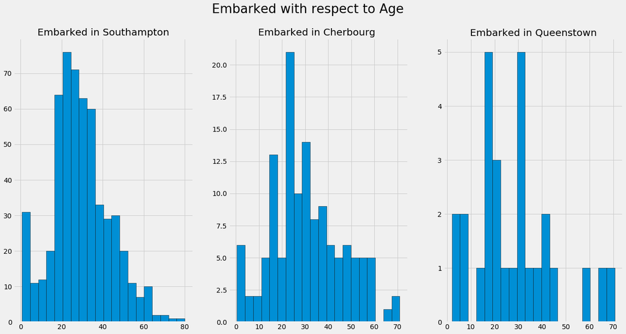

```python
fig,ax=plt.subplots(1,3,figsize=(20,10))
fig.suptitle('Embarked with respect to Age', fontsize=26)

titanic_df[titanic_df['Embarked']=='S'].Age.plot.hist(ax=ax[0],bins=20,edgecolor='black')
ax[0].set_title('Embarked in Southampton')
ax[0].set_ylabel('')

titanic_df[titanic_df['Embarked']=='C'].Age.plot.hist(ax=ax[1],bins=20,edgecolor='black')
ax[1].set_title('Embarked in Cherbourg ')
ax[1].set_ylabel('')

titanic_df[titanic_df['Embarked']=='Q'].Age.plot.hist(ax=ax[2],bins=20,edgecolor='black')
ax[2].set_title('Embarked in Queenstown')
ax[2].set_ylabel('')

plt.show()
```

Age does not provide us with any useful information.

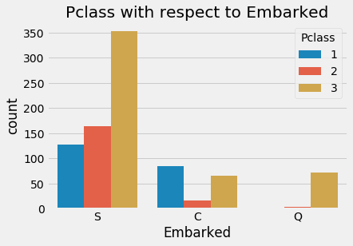

```python
sns.countplot('Embarked', hue='Pclass', data=titanic_df)
plt.title('Pclass with respect to Embarked')
plt.show()
```

```python
print('Queenstown first class tickets:', len(titanic_df.loc[(titanic_df.Embarked=='Q') & (titanic_df.Pclass==1)]))
print('Queenstown second class tickets:',len(titanic_df.loc[(titanic_df.Embarked=='Q') & (titanic_df.Pclass==2)]))
print('Cherbourg  first class tickets:',len(titanic_df.loc[(titanic_df.Embarked=='C') & (titanic_df.Pclass==1)]))
```

```
Queenstown first class tickets: 2
Queenstown second class tickets: 3
Cherbourg  first class tickets: 85
```

From the above information we understand that the difference in the survival rate is due to the class of tickets.

## General Conclusion:

# Data Wrangling

We already know that Age feature is missing 177 values, Cabin 687 and Embarked 2. These results are presented below in the form of a graph.

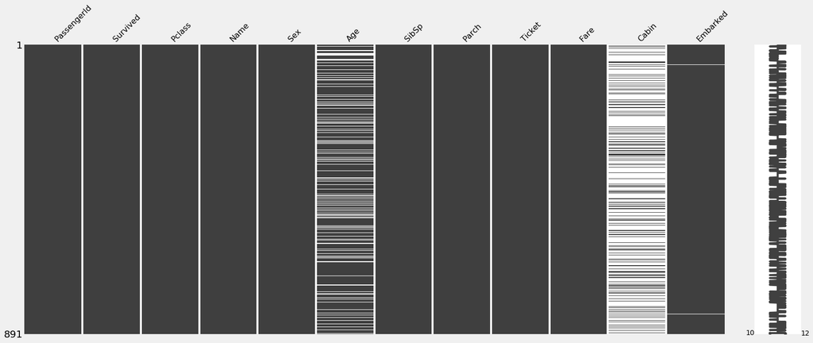

```python
missingno.matrix(titanic_df)
plt.show()
```

Cabin column has too many values to be used in the current analysis.

```python
# Drop cabin column
titanic_df.drop('Cabin', axis=1, inplace=True)
```

Age and Embarked NaN values could be filled but would be left out of the scope of the current prediction.

```python
# Drop the remaining NaN values
titanic_df.dropna(inplace=True)
```

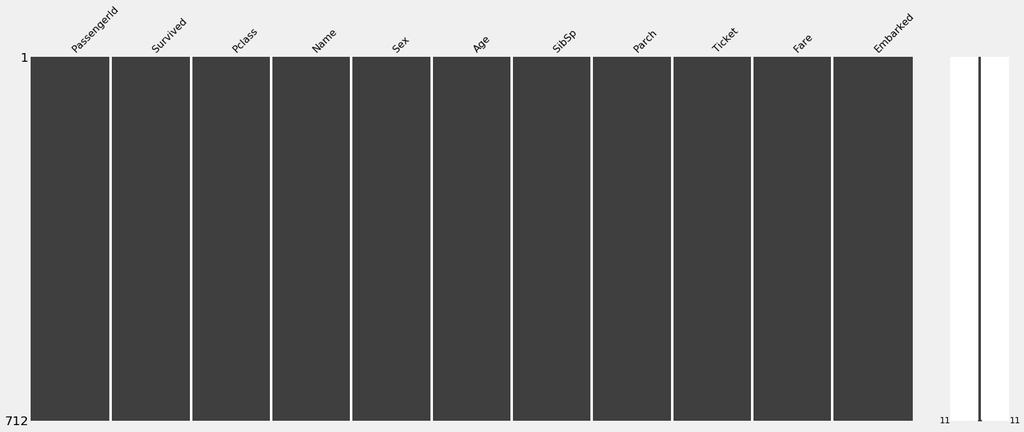

```python
missingno.matrix(titanic_df)
plt.show()
```

There is no missing value in our dataset.

```python
sex = pd.get_dummies(titanic_df['Sex'], drop_first=True)
sex.head()
```

|  | male |
| --- | --- |
| 0 | 1 |
| 1 | 0 |
| 2 | 0 |
| 3 | 0 |
| 4 | 1 |

```python
embark = pd.get_dummies(titanic_df['Embarked'], drop_first=True)
embark.head()
```

|  | Q | S |
| --- | --- | --- |
| 0 | 0 | 1 |
| 1 | 0 | 0 |
| 2 | 0 | 1 |
| 3 | 0 | 1 |
| 4 | 0 | 1 |

```python
pcl = pd.get_dummies(titanic_df['Pclass'], drop_first=True)
pcl.head()
```

|  | 2 | 3 |
| --- | --- | --- |
| 0 | 0 | 1 |
| 1 | 0 | 0 |
| 2 | 0 | 1 |
| 3 | 0 | 0 |
| 4 | 0 | 1 |

```python
titanic_df = pd.concat([titanic_df, sex, embark, pcl], axis=1)
titanic_df.head()
```

|  | PassengerId | Survived | Pclass | Name | Sex | Age | SibSp | Parch | Ticket | Fare | Embarked | male | Q | S | 2 | 3 |
| --- | --- | --- | --- | --- | --- | --- | --- | --- | --- | --- | --- | --- | --- | --- | --- | --- |
| 0 | 1 | 0 | 3 | Braund, Mr. Owen Harris | male | 22.0 | 1 | 0 | A/5 21171 | 7.2500 | S | 1 | 0 | 1 | 0 | 1 |
| 1 | 2 | 1 | 1 | Cumings, Mrs. John Bradley (Florence Briggs Th... | female | 38.0 | 1 | 0 | PC 17599 | 71.2833 | C | 0 | 0 | 0 | 0 | 0 |
| 2 | 3 | 1 | 3 | Heikkinen, Miss. Laina | female | 26.0 | 0 | 0 | STON/O2. 3101282 | 7.9250 | S | 0 | 0 | 1 | 0 | 1 |
| 3 | 4 | 1 | 1 | Futrelle, Mrs. Jacques Heath (Lily May Peel) | female | 35.0 | 1 | 0 | 113803 | 53.1000 | S | 0 | 0 | 1 | 0 | 0 |
| 4 | 5 | 0 | 3 | Allen, Mr. William Henry | male | 35.0 | 0 | 0 | 373450 | 8.0500 | S | 1 | 0 | 1 | 0 | 1 |

```python
titanic_df.drop(['Pclass', 'Sex', 'Embarked', 'PassengerId', 'Name', 'Ticket'], axis=1, inplace=True)
titanic_df.head()
```

|  | Survived | Age | SibSp | Parch | Fare | male | Q | S | 2 | 3 |
| --- | --- | --- | --- | --- | --- | --- | --- | --- | --- | --- |
| 0 | 0 | 22.0 | 1 | 0 | 7.2500 | 1 | 0 | 1 | 0 | 1 |
| 1 | 1 | 38.0 | 1 | 0 | 71.2833 | 0 | 0 | 0 | 0 | 0 |
| 2 | 1 | 26.0 | 0 | 0 | 7.9250 | 0 | 0 | 1 | 0 | 1 |
| 3 | 1 | 35.0 | 1 | 0 | 53.1000 | 0 | 0 | 1 | 0 | 0 |
| 4 | 0 | 35.0 | 0 | 0 | 8.0500 | 1 | 0 | 1 | 0 | 1 |

# Train and Test Data

```python
X = titanic_df.drop('Survived', axis=1)
y = titanic_df.Survived
```

```python
X_train, X_test, y_train, y_test = train_test_split(X, y, test_size=0.3, random_state=50)
```

### Logistic Regression

```python
model = LogisticRegression()
model.fit(X_train, y_train)
print('accuracy =', model.score(X_test, y_test))
LogRegPred = model.predict(X_test)
```

```
accuracy = 0.8317757009345794
```

### Naive Bayes

```python
model = GaussianNB()
model.fit(X_train, y_train)
print('accuracy =', model.score(X_test, y_test))
```

```
accuracy = 0.7850467289719626
```

### K-Nearest Neighbors

```python
model = KNeighborsClassifier(n_neighbors=3)
model.fit(X_train, y_train)
print('accuracy =', model.score(X_test, y_test))
```

```
accuracy = 0.7383177570093458
```

### Decision Tree

```python
model = DecisionTreeClassifier()
model.fit(X_train, y_train)
print('accuracy =', model.score(X_test, y_test))
```

```
accuracy = 0.7757009345794392
```

### Random Forest

```python
model = RandomForestClassifier()
model.fit(X_train, y_train)
print('accuracy =', model.score(X_test, y_test))
```

```
accuracy = 0.8317757009345794
```

### Support Vector Machines

```python
model = svm.SVC()
model.fit(X_train, y_train)
print('accuracy =', model.score(X_test, y_test))
```

```
accuracy = 0.6915887850467289
```

```python
print(classification_report(y_test, LogRegPred))
```

```
              precision    recall  f1-score   support

           0       0.84      0.89      0.87       130
           1       0.82      0.74      0.78        84

    accuracy                           0.83       214
   macro avg       0.83      0.82      0.82       214
weighted avg       0.83      0.83      0.83       214
```

```
Confusion matrix, without normalization
[[116  14]
 [ 22  62]]
Normalized confusion matrix
[[0.89230769 0.10769231]
 [0.26190476 0.73809524]]
```

[figure not shown]

[figure not shown]

```python
# Plot non-normalized confusion matrix
model = LogisticRegression()
model.fit(X_train, y_train)
titles_options = [("Confusion matrix, without normalization", None),
                  ("Normalized confusion matrix", 'true')]
for title, normalize in titles_options:
    disp = plot_confusion_matrix(model, X_test, y_test,
                                 display_labels='Survived',
                                 cmap=plt.cm.Blues,
                                 normalize=normalize)
    disp.ax_.set_title(title)

    print(title)
    print(disp.confusion_matrix)

plt.show()
```